# act_report

## Report: act_report

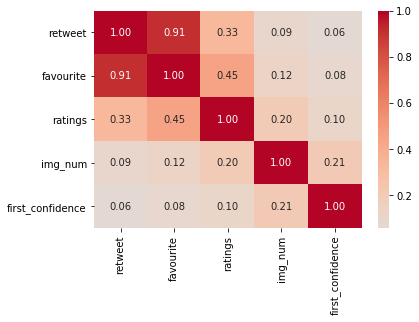

Among the numerical variables in our dataset, there are correlations between the Retweet, Favourite and Ratings. This is to say that the higher the Retweet count, the higher the Favourite count and the higher the Ratings, the higher the Retweet/Favourite count.

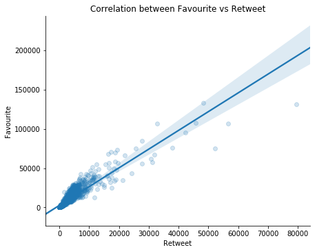

Using plots to visually confirm the correlation between the Retweet and Favourite variables, only few tweets get high retweet and the highest retweet is about 78,000.

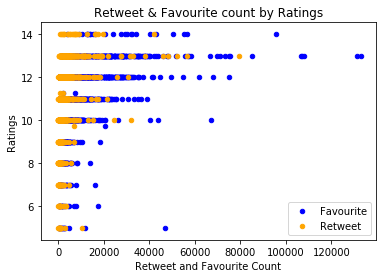

The correlation between the Ratings and Favourite/Retweet count shows that the higher the rating, the higher the retweet and favourite count. From the analysis, the Favourite count is always bigger than the Retweet count. The highest Retweet and Favourite count in the dataset was at a rating of 13, where the retweet was about 78,000 while the favourite was above 130,000.

###### Top Rated Dog Breed

Pembroke, Golden retriever, French bulldog, Pomeranian, Military uniform, Rottweiler, Old english sheepdog, Chihuahua, Black-and-tan coonhound, Irish setter, Lakeland terrier, Gordon setter, Samoyed, Bedlington terrier, Bloodhound, Laptop, Standard poodle, Eskimo dog are among the highest rated dogs with a rating of 14 in the dataset. Here is what a Top Rated Pembroke dog look like.

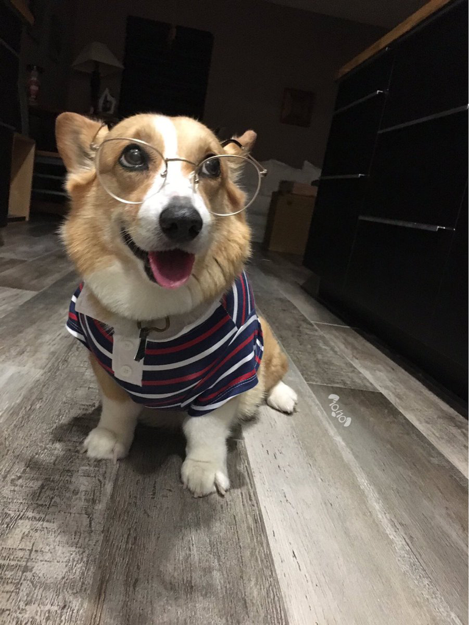

###### Common Dog Names

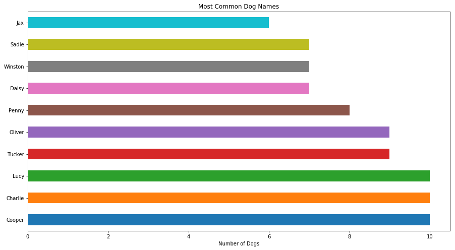

Cooper, Lucy and Charlie and the top most common names given to dogs in our dataset.

###### Most Common Dog Breed

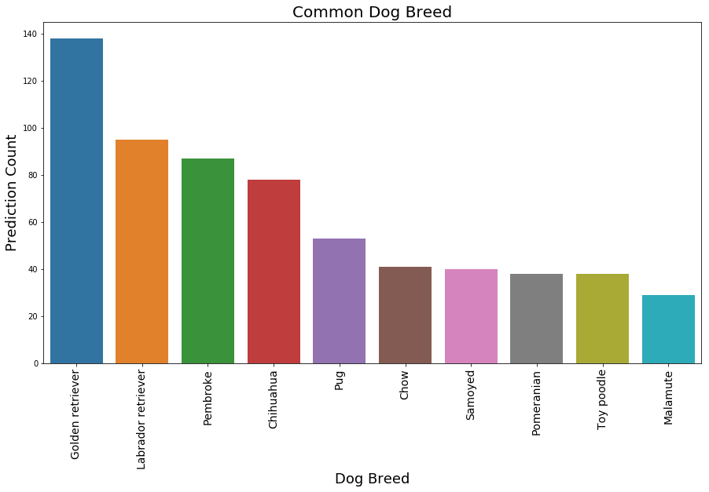

Golden retriever is the most common Dog breed among the dataset with a value count of 138. Here is what a Golden retriever look like.

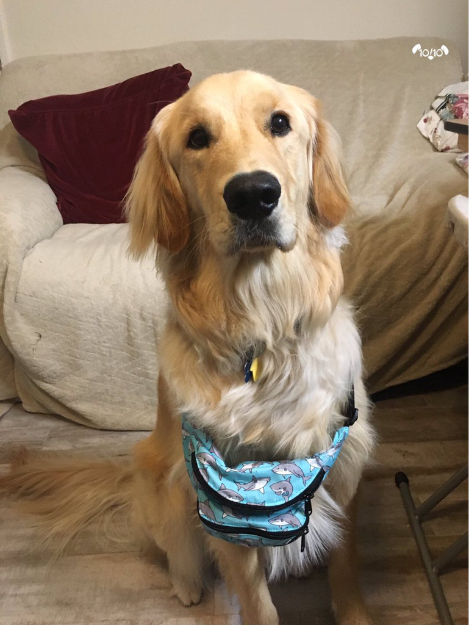

###### Most Common Dog Stage

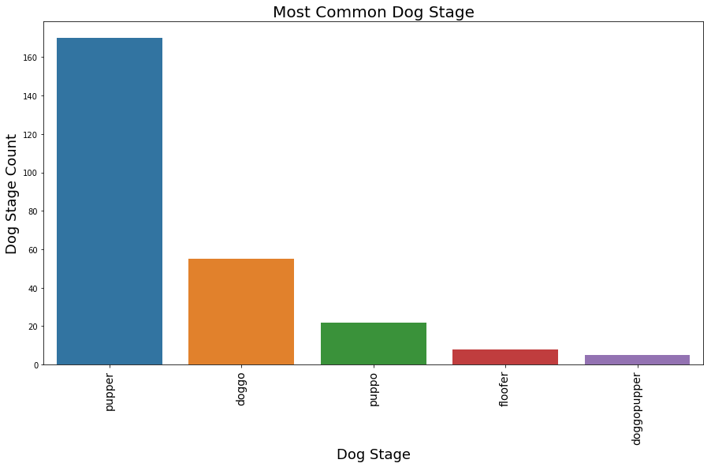

From the analysis, pupper is seen to be the most common dog stage with a value count of 170. The downside to this is that not all data in the dataset have a dog stage.

###### Top 10 Most Favourite Dog Breed

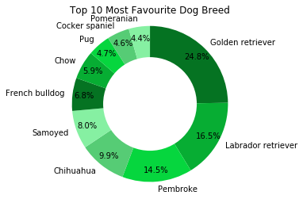

Golden retriever is seen to be the most Favourite/loved dog breed with an overall favourite count of 1,690,700. Among the top ten (10) favourite dog breed analysed, the Golden retriever have about 24.8% of the overall top ten favourite count.

###### Top 10 Most Retweeted Dog Breed

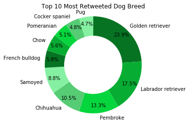

Golden retriever is also the most shared tweet among the dataset with an overall retweet count of 500441, and among the top ten (10) most retweeted dog breed, the Golden retriever have about 23.9%.